# Mini-project-II

Aditi Mulye, Keshav Likhar, Nikunj Malpani

## Introduction

Many people studying politics in the United States believe that the country is becoming more ideologically polarized: either liberals are becoming more liberal, conservatives are becoming more conservative, or both. In either case, they believe that the middle of the political spectrum is being hollowed out.

For the purpose of this project, we had been given a dataset consisting of voting data of different members of the senate ranging from year 1989 to 2014. Now, we will be using this vast and rich data to evaluate the change in polarity of members of the Senate over the years.

Let’s see how we are able to gain insights from this data!

### Data Description:

We have records of Members and votes from year 1989 through 2014.

- senator’s vote on each of the bills for which there was a roll call vote in that year and description of the senators (name, id, state, party).
- For most of the bills, the senators vote with “yea”, “nay” or abstain from taking part in the voting process.

Thus, in order to conduct a statistical analysis, our first task was to reassign a numeric value of 1 (“yea”) and 0 (“nay”) and -1 (otherwise”).

### Problem statement:

To find the political ideologies of the people studying politics in the United States who believe that the country is becoming more ideologically polarized

## Data Preparation

One of the major tasks in the project was to deal with such huge amount of data of over 25 years with 2 csv files for each year. We came up with an idea of minimizing our efforts by making various functions for reading different files, deadling with null and categorical values as well as drawing plots for analysing our results, thus helping us reduce repititive efforts.

### MDS or Multidimensional Scaling Plots for describing the relationships in several years

Multidimensional scaling (MDS) is a technique for visualizing distances between objects, where the distance is known between pairs of the objects. Here, we used cmdscale() which is a stats package and is used to compute classical (metric) multidimensional scaling. The advantage with MDS is that you can specify the number of dimensions you want in the output data.

### Comparision of Polarization for two years

To determine whether American politics is becoming more ideologically polarized, that is, whether liberals are becoming more liberal, conservatives are becoming more conservative, or both, the first step we took was to try to understand how the ideologies of both parties have changed over time, that is, how they are now compared to how they were previously. We achieved this by looking at all of the senators’ voting records from a previous session (1989) and a later session (2014), assuming that there would be a considerable difference in polarization between the two years.

We have used multi-dimensional scaling on a measure of **Eucladian Distance** between senators for both the years and finally plotted those distances in two seperate graphs that can be clearly seen below.

One of the most important things we considered before drawing the plots for both the years was to ensure that they lie on the same scale. This was necessary as it helped us compare the two years in a fair and efficient manner.

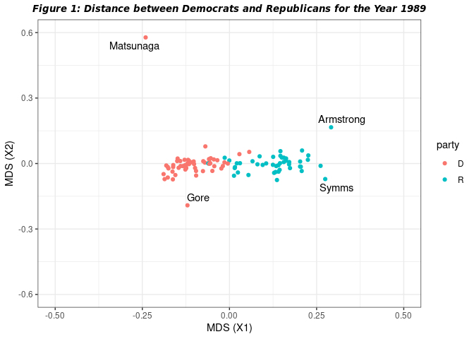

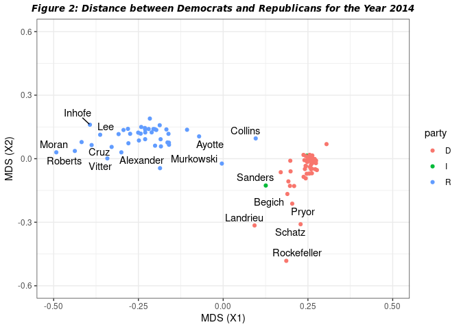

- In the above figure (Figure 2), for year 2014, it has been noted that a new party, the Independent Party, has emerged, consisting of senator who has an independent viewpoint. Senator Sanders is a member of the Independent Party, yet he appears to be more aligned with the Democratic Party than the Republican Party, as seen by his closeness to the Democratic Party.
- Just a single look at the figure helps us conclude that the difference between the cluster means of both the groups has increased than for year 1989. The patterns between the two years are not very similar to each other and appears more 2-D than for the year 1989. The number of outliers for both the groups have also increased in 2014.
- Additionally, we can also notice that a new party has come up in 2014 with only one data point and the points seem to be more dispersed for **Republicans** than for the **Democrats**. We may also say that polarity has increased in 2014 than what it was in 1989.

> Therefore, we establish that there is a certain increase in polarity from 1989 to 2014. To dive deeper into the investigation, we probe into its trend systematically over time.

### Evaluation of Polarization over time

From the investigations conducted above, it was observed that the X1 component of MDS captured significant amount of variations in data. Therefore, one way of investigating the polarization over time would be to study the differences between the means of the clusers formed for both the groups over the years.

- For calculating the mean distances of clusters between **Democrats** and **Republicans**, we considered X1, X2 for both the parties and then calculated the Euclidean Distance, thus helping us capture the dissimilarities between the two groups.
- The methodology we used here was to consider the X1, X2 component of MDS with their repsective years for **Democrats** and **Republicans** and then use it to calculate the Euclidean distance.

### Euclidean Distance

$$d(a,b) = \sqrt{\sum_{i=1}^n(a_i -
b_i)^2}$$

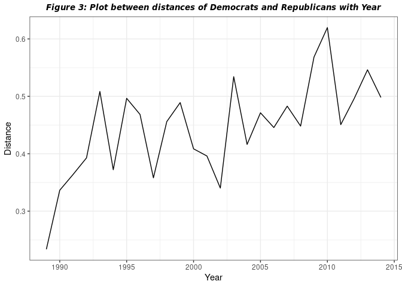

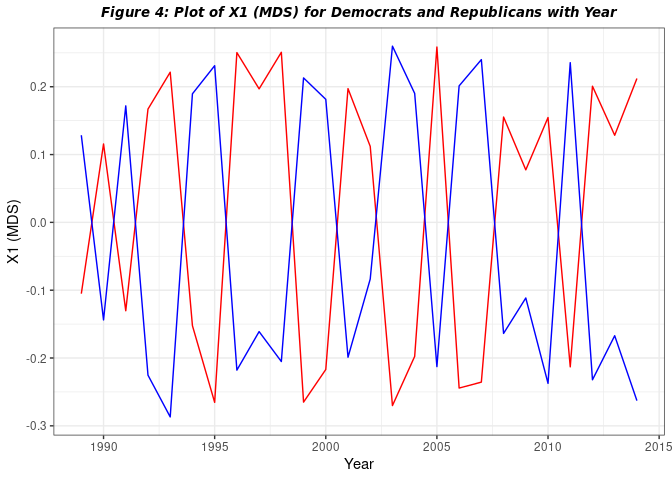

- In Figure 4, we have plotted X1 component of MDS for **Republicans** as well as **Democrats**. It is really interesting to know that the gap between the parties has increased with time, but they seem to switch sides for almost every other year.
- We weren’t able to figure out why exactly there was a flip happening for **Democrats** as well as **Republicans** for almost every other year. One of the initial guesses that we came up with was that the ruling party might be changing for every other year, thus resulting in a chnage in their sides with respect to a bill for a given year.
- Successively, we were also able to conclude that the polarization and distances between the two parties was not due to any one particular party, but, both the parties contributed equally in it.
- Finally, it may be claimed that party polarization has intensified in recent years, and senators have backed up the parties when they most needed unity. However, there may be numerous elements that influence the senator’s judgment on bills that are beyond the purview of these visualizations, and thus reaching conclusions like this when there is only one factor, the variance, may not be valid.
- We can see that there is a significant decrease in the polarization in 2001 and 2002, this might be because of 9/11 incident and after that many bills may be passed and agreed upon by both the parties keeping politics aside and supporting the nation. For year, 2009 and 2010 we can see that there is a significant increase in the polarization, this might be because of the US financial crisis, leading to severe worldwide economic crisis. This might have caused the opposition party to put the blame on the ruling party and thus rejecting or opposing the bills.

### Ideological position of one senator

Since we had already looked into the change in polarity of the two parties over the years, we were also interested in knowing if there was a particular senator who was influencing this change.

One approach to begin answering this challenge was to look at a particular senator who served each year and compare the parties to that senator. We measured the two parties’ positions relative to the senator if the senator’s politics haven’t changed over time.

The approach we took for performing this action can be listed in the following steps:

- Identify all of the senators who voted on bills over the years.
- Choose a senator who can assist us understand their polarity in relation to a particular political party.

Now after Step 1, we found a set of ~15 senators who were present in all the datasets. Now, to choose a senator, we plotted a graph like the one below [Fig 5] for all of them and checked the trends.

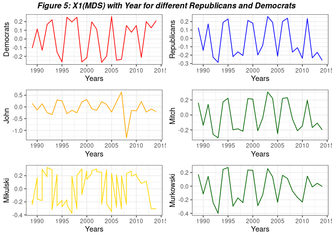

Since, there are few members who changed their views with time from their respective political parties, we cannot assign the blame to one or the other members or parties for polarization. Their might be different reasons for it.

### Conclusion:

- We notice that there has been an increase in polarization between the two parties over the years (relative distances has increased with time). From the observations made above [Fig 4], one could speculate whether Republicans have become more conservative over the years. However, we also notice that with the increased polarization between the two parties, most of the senators have changed their stand over the years in support of the parties that they belong to.
- Finally, it may be argued that party polarization has increased in recent years, and senators have backed up the parties at a time when they needed unity the most. However, there may be a number of factors that influence a senator’s decision on a bill that are outside the scope of these visualizations, thus drawing conclusions based on only one aspect, may not be valid.